# Rozkłady zmiennej losowej

## Wprowadzenie do prawdopodobieństwa + rozkład zmiennej losowej

**Na podstawie filmow, odpowiedz na pytania:**

- [Co to jest prawdopodobienstwo?](https://www.youtube.com/watch?v=7Y1ns_HLZow)
- [Co to jest zmienna losowa?](https://www.youtube.com/watch?v=wzJSKRVnil4&t=290s)
- Co to jest rozklad zmiennej losowej?

## Rozkłady zmiennej losowej

- **Rozklad dwumianowy**
- Rozkład Poissona
- Rozkład jednostajny
- **Rozkład normalny**
- Rozkład chi-kwadrat
- Rozkład Studenta

## Rozkład dwumianowy

### **Rozkład dwumianowy**

to dyskretny rozkład prawdopodobieństwa opisujący liczbę sukcesów w ciągu niezależnych prób, z których każda ma stałe prawdopodobieństwo sukcesu.

### **Przykłady**:

- rzut monetą
- rzut kostką
- losowanie z talii kart

## Rozkład dwumianowy w R

### **Cztery dostępne funkcje:**

- funkcja gestosci prawdopodobienstwa *dbinom()* - okresla prawdopodobienstwo, ze zmienna losowa przyjmie daną wartość x

## Rozkład dwumianowy w R

### **Cztery dostępne funkcje:**

- funkcja gestosci prawdopodobienstwa *dbinom()* - okresla prawdopodobienstwo, ze zmienna losowa przyjmie daną wartość x
- dystrybuanta *pbinom()* - określa prawdopodobieństwo tego, ze dana zmienna losowa przyjmie wartość równą bądź mniejszą x

## Rozkład dwumianowy w R

### **Cztery dostępne funkcje:**

- funkcja gestosci prawdopodobienstwa *dbinom()* - okresla prawdopodobienstwo, ze zmienna losowa przyjmie daną wartość x
- dystrybuanta *pbinom()* - określa prawdopodobieństwo tego, ze dana zmienna losowa przyjmie wartość równą bądź mniejszą x
- generator liczb losowych *rbinom()*
- funkcja kwantylowa - odwrotna dystrybuanta *qbinom()* - przypisuje konkretne wartości dla danego obszaru (sumy) prawdopodobieństwa

## Zadanie 1

Jakie jest prawdopodobienstwo wypadniecia orła 3 razy podczas 6 rzutow moneta?

## Zadanie 1

Jakie jest prawdopodobienstwo wypadniecia orła 3 razy podczas 6 rzutow moneta?

```r
# dbinom - density function binomial
help(dbinom)
dbinom(x=3, size=6, prob=0.5)
```

```
## [1] 0.3125
```

## Zadanie 2

Jakie jest prawdopodobienstwo wypadniecia maksymalnie 3 orlow podczas 6 rzutow moneta?

## Zadanie 2

Jakie jest prawdopodobienstwo wypadniecia maksymalnie 3 orlow podczas 6 rzutow moneta?

```r
# pbinom - distribution function binomial
help(pbinom)
pbinom(q=3, size=6, prob=0.5)
```

```
## [1] 0.65625
```

## Zadanie 3

Rzucamy 1000 razy symetryczną monetą, a rezultaty zapisujemy w wektorze “moneta”. Ile razy wypada orzeł?

- Sposób pierwszy (rbinom)

## Zadanie 3

Rzucamy 1000 razy symetryczną monetą, a rezultaty zapisujemy w liście “moneta”. Ile razy wypada orzeł?

- Sposób pierwszy (rbinom)

```r
# rbinom - random number binomial
help(rbinom)
n <- 1000
size <- 1
prob <- 0.5
moneta <- rbinom(n, size, prob)
table(moneta)
```

```
## moneta
##   0   1
## 483 517
```

## Zadanie 3

Rzucamy 1000 razy symetryczną monetą, a rezultaty zapisz w liście “moneta”. Ile razy wypadł orzeł?

- Sposób drugi (sample)

## Zadanie 3

Rzucamy 1000 razy symetryczną monetą, a rezultaty zapisz w liście “moneta”. Ile razy wypadł orzeł?

- Sposób drugi (sample)

```r
help(sample)
moneta <- sample(c("orzel", "reszka"), size=1000,
                 replace=TRUE)
table(moneta)
```

```
## moneta
##  orzel reszka
##    471    529
```

## Zadanie 4

Narysuj funkcje rozkladu (gęstości) prawdopodobienstwa wypadniecia orla w 100 rzutach moneta

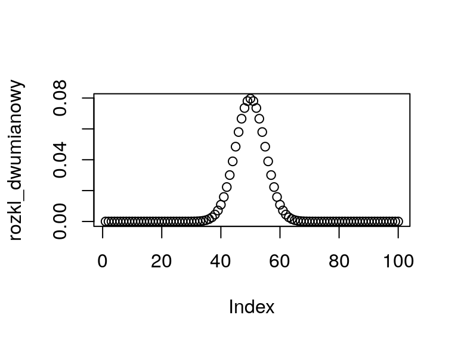

```r
rozkl_dwumianowy <- dbinom(1:100, size=100, prob=0.5)
plot(rozkl_dwumianowy)
```

## Zadanie 4 - cd

Narysuj funkcje rozkladu (gęstości) prawdopodobienstwa wypadniecia orla w 100 rzutach moneta - opcje wykresu.

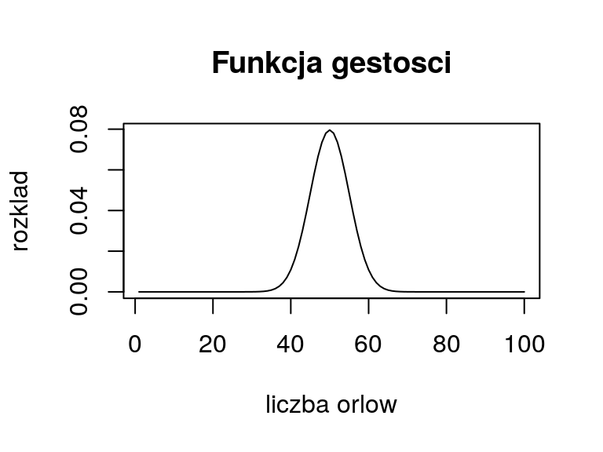

```r
help(plot)
rozklad <- dbinom(1:100, size=100, prob=0.5)
plot(rozklad, main="Funkcja gestosci",
     xlab="liczba orlow", type="l")
```

## Zadanie 5

Narysuj dystrybuante dla prawdopodobienstwa wypadniecia orla podczas 100 rzutow symetryczna moneta

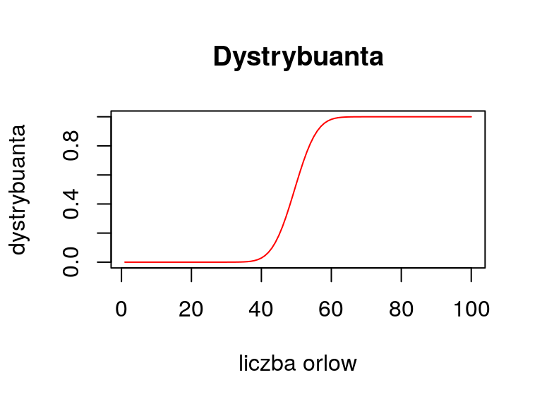

```r
dystrybuanta <- pbinom(1:100, size=100, prob=0.5)
plot(dystrybuanta, main="Dystrybuanta",
     xlab="liczba orlow", type="l", col="red")
```

## Zadanie 6

- Narysuj dystrybuante dla prawdopodobienstwa wypadniecia orla podczas 100 rzutow symetryczna moneta.
- Grubosc linii = 2, typ wykresu = kola i linia

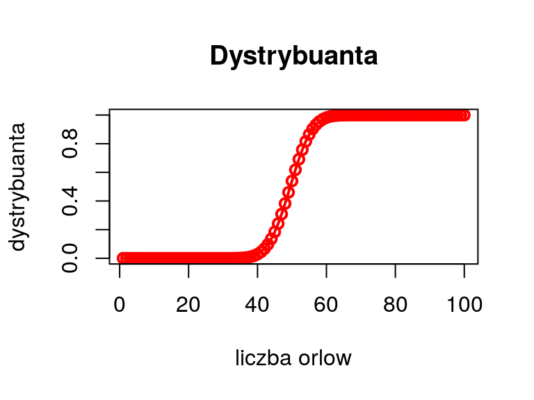

```r
dystrybuanta <- pbinom(1:100, size=100, prob=0.5)
plot(dystrybuanta, main="Dystrybuanta",
     xlab="liczba orlow", type="o", lwd=2, col="red")
```

## Zadanie domowe

1. Oblicz prawodopodobienstwo tego, ze podczas 60 rzutow moneta orzel wypadnie
- 20,25 lub 30 razy
- mniej niz 20 razy
- pomiedzy 20 a 30 razy
1. Wyobraz sobie, ze na zaliczenie ze statystyki masz test skladajacy sie z 12 pytan. Kazde pytanie sklada sie z 5 mozliwych odpowiedzi, z ktorych tylko jedna jest poprawna. Jakie jest prawdopodobienstwo poprawnego trafienia 4 lub mniej pytan?
2. Narysuj funkcję gęstości (rozkładu) prawdopodobieństwa oraz dystrybuante dla rozkładu Poisssona oraz Studenta. Jakie są zastosowania rozkładów?